# bike_demand_prediction

## Prediction For Bike Sharing Demand in Seoul

Doğukan E. Türköz

In an article [*] featured in the "Computer Communications" journal, the authors considered data for bike sharing demand in Seoul. The data includes weather information (Temperature, Humidity, Windspeed, Visibility, Dewpoint, Solar radiation, Snowfall, Rainfall), the number of bikes rented per hour and date information. We will work with an already preprocessed version of the original dataset and attempt to predict bike demand using a linear regression model, a decision tree regressor model, and a random forest regressor model respectively.

[*] Sathishkumar V E, Jangwoo Park, Yongyun Cho. 'Using data mining techniques for bike sharing demand prediction in metropolitan city.' Computer Communications, Vol.153, pp.353-366, March, 2020. [link](https://doi.org/10.1016/j.comcom.2020.02.007).

### EDA

We import the necessary libraries, read the data into a pandas dataframe, and display the first five rows of the data.

```python
import numpy as np
import matplotlib.pyplot as plt
import pandas as pd
import seaborn as sns

from sklearn import linear_model, tree
from sklearn.preprocessing import StandardScaler
from sklearn.model_selection import train_test_split, GridSearchCV
from sklearn.metrics import r2_score, mean_absolute_error, mean_squared_error
from sklearn.tree import DecisionTreeRegressor
from sklearn.ensemble import RandomForestRegressor
```

```python
df = pd.read_csv("SeoulBikeData_mod.csv")
df.head()
```

|  | Rented Bike Count | Hour | Temperature(°C) | Humidity(%) | Wind speed (m/s) | Visibility (10m) | Dew point temperature(°C) | Solar Radiation (MJ/m2) | Rainfall(mm) | Snowfall (cm) | Month |
| --- | --- | --- | --- | --- | --- | --- | --- | --- | --- | --- | --- |
| 0 | 206 | 0 | -3.2 | 40 | 0.5 | 1358 | -14.9 | 0.0 | 0.0 | 0.0 | 1 |
| 1 | 230 | 1 | -3.3 | 41 | 0.7 | 2000 | -14.7 | 0.0 | 0.0 | 0.0 | 1 |
| 2 | 178 | 2 | -3.7 | 42 | 0.9 | 2000 | -14.7 | 0.0 | 0.0 | 0.0 | 1 |
| 3 | 119 | 3 | -4.0 | 44 | 1.0 | 2000 | -14.4 | 0.0 | 0.0 | 0.0 | 1 |
| 4 | 62 | 4 | -4.2 | 53 | 1.1 | 1994 | -12.3 | 0.0 | 0.0 | 0.0 | 1 |

We see that the data consists of integers and floats. We also note that since "Month" is a nominal variable, it has been integer encoded.

```python
df.info()
```

```
<class 'pandas.core.frame.DataFrame'>
RangeIndex: 4416 entries, 0 to 4415
Data columns (total 11 columns):
 #   Column                     Non-Null Count  Dtype
---  ------                     --------------  -----
 0   Rented Bike Count          4416 non-null   int64
 1   Hour                       4416 non-null   int64
 2   Temperature(°C)            4416 non-null   float64
 3   Humidity(%)                4416 non-null   int64
 4   Wind speed (m/s)           4416 non-null   float64
 5   Visibility (10m)           4416 non-null   int64
 6   Dew point temperature(°C)  4416 non-null   float64
 7   Solar Radiation (MJ/m2)    4416 non-null   float64
 8   Rainfall(mm)               4416 non-null   float64
 9   Snowfall (cm)              4416 non-null   float64
 10  Month                      4416 non-null   int64
dtypes: float64(6), int64(5)
memory usage: 379.6 KB
```

We now display common measures of statistics for all features and the target variable "Rented Bike Count".

```python
df.describe()
```

|  | Rented Bike Count | Hour | Temperature(°C) | Humidity(%) | Wind speed (m/s) | Visibility (10m) | Dew point temperature(°C) | Solar Radiation (MJ/m2) | Rainfall(mm) | Snowfall (cm) | Month |
| --- | --- | --- | --- | --- | --- | --- | --- | --- | --- | --- | --- |
| count | 4416.000000 | 4416.00000 | 4416.000000 | 4416.000000 | 4416.000000 | 4416.000000 | 4416.000000 | 4416.000000 | 4416.000000 | 4416.000000 | 4416.000000 |
| mean | 704.591259 | 11.50000 | 13.203986 | 59.257246 | 1.653193 | 1398.641304 | 4.723958 | 0.560181 | 0.139312 | 0.070879 | 5.956522 |
| std | 637.407244 | 6.92297 | 11.529724 | 20.162981 | 0.976361 | 621.560536 | 12.671445 | 0.860496 | 1.145271 | 0.437416 | 3.407262 |
| min | 0.000000 | 0.00000 | -17.800000 | 0.000000 | 0.000000 | 27.000000 | -30.600000 | 0.000000 | 0.000000 | 0.000000 | 1.000000 |
| 25% | 189.000000 | 5.75000 | 4.500000 | 44.000000 | 0.900000 | 853.000000 | -3.500000 | 0.000000 | 0.000000 | 0.000000 | 3.000000 |
| 50% | 542.000000 | 11.50000 | 14.300000 | 58.000000 | 1.500000 | 1621.000000 | 6.400000 | 0.010000 | 0.000000 | 0.000000 | 5.000000 |
| 75% | 1047.000000 | 17.25000 | 22.200000 | 75.000000 | 2.200000 | 1999.000000 | 14.900000 | 0.910000 | 0.000000 | 0.000000 | 9.000000 |
| max | 3298.000000 | 23.00000 | 38.000000 | 98.000000 | 6.700000 | 2000.000000 | 26.800000 | 3.520000 | 35.000000 | 8.800000 | 11.000000 |

We use a heatmap to produce a colored correlation plot. The plot shows that temperature and hour both have moderate positive correlation with the rented bike count.

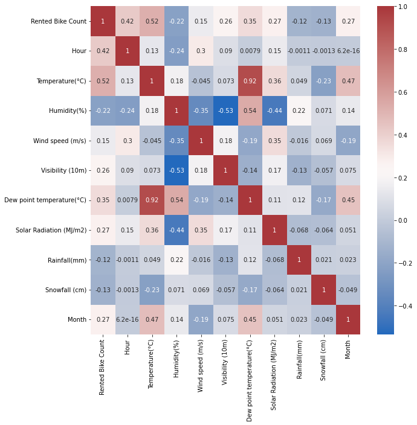

```python
plt.figure(figsize = (10,10))
sns.heatmap(df.corr(), annot=True, cmap = "vlag")
plt.show()
```

From the box plot we see that the frequency of the rented bike counts has a positive (right) skew.

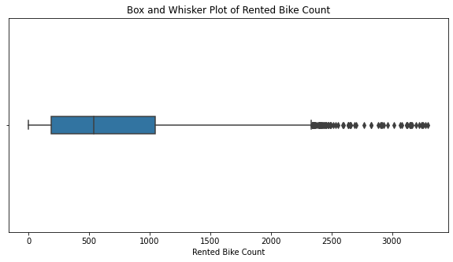

```python
rents = "Rented Bike Count"
figure = plt.figure(figsize=(10,5))
sns.boxplot(x=df[rents])
plt.ylim(-5,5)
plt.title("Box and Whisker Plot of Rented Bike Count")
plt.show()
```

We now display a line plot of rents vs. temperature. From the plot we see that the rented bike count seems to increase with temperature.

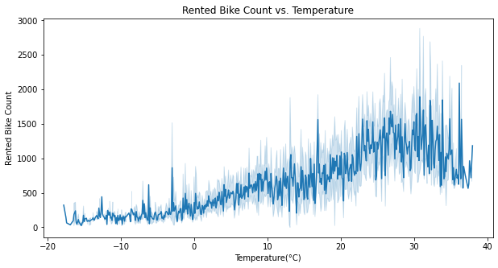

```python
figure = plt.figure(figsize=(10,5))
sns.lineplot(y=rents, x="Temperature(°C)", data=df)
plt.title("Rented Bike Count vs. Temperature")
plt.show()
```

We now display a violin plot of rents vs. month. From the plot we see that the rented bike count decreases significantly in winter.

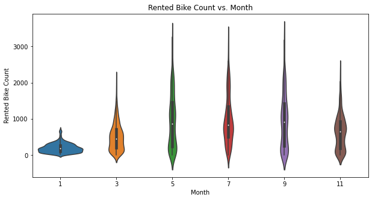

```python
figure = plt.figure(figsize=(10,5))
sns.violinplot(y=rents, x="Month", data=df)
plt.title("Rented Bike Count vs. Month")
plt.show()
```

We now display a bar plot of rents vs. hour. From the plot we see that the rented bike count decreases significantly during midnight to 6 A.M.

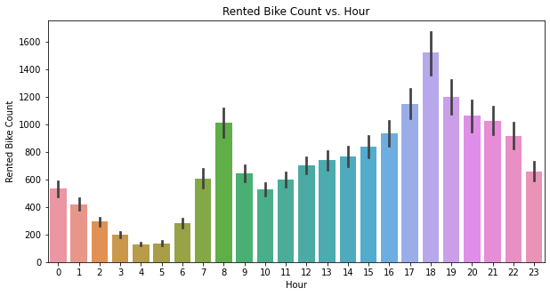

```python
figure = plt.figure(figsize=(10,5))
sns.barplot(y=rents, x="Hour", data=df)
plt.title("Rented Bike Count vs. Hour")
plt.show()
```

### A tad bit of preprocessing

```python
scaler = StandardScaler()
scaled = scaler.fit_transform(df)
```

We now partition the dataframe into the features matrix and the target vector.

```python
X = df.drop(rents, axis=1)
y = df[rents]
```

We will use 75 % of the data for training our model and the rest for testing.

```python
X_train, X_test, y_train, y_test = train_test_split(X, y, test_size=0.25)
```

### Linear Regression

We will first try a linear regression model.

```python
model = linear_model.LinearRegression()
model.fit(X_train, y_train)
y_pred = model.predict(X_test)
```

By plotting histograms of the test set and our predictions, we see that the linear model does not perform well.

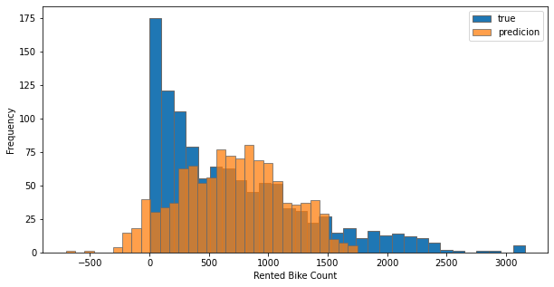

```python
figure = plt.figure(figsize=(10,5))
plt.hist(y_test, bins=31, label="true", edgecolor = 'dimgray')
plt.hist(y_pred, bins=31, label="predicion", alpha = 0.75, edgecolor = 'dimgray')
plt.legend()
plt.xlabel(rents)
plt.ylabel("Frequency")
plt.show()
```

To test the performance of the model the following performance assessment indices will be used:

```python
print("R-squared:", (r2_score(y_test, y_pred)))
print("MAE:",(mean_absolute_error(y_test, y_pred)))
print("RMSE:", mean_squared_error(y_test, y_pred, squared = False))
```

```
R-squared: 0.4564260955736187
MAE: 342.1066119808671
RMSE: 466.72013750783873
```

We could try to improve our linear regressor model by tuning it; however, it is clear that the data does not follow a linear relationship.

### Decision Tree Regressor

We now try a decision tree regressor. Since decision trees support non-linearity, we hope for a more accurate model.

```python
model2 = DecisionTreeRegressor(random_state=2022)
model2.fit(X_train, y_train)
y_pred2 = model2.predict(X_test)

print("R-squared:", (r2_score(y_test, y_pred2)))
print("MAE:",(mean_absolute_error(y_test, y_pred2)))
print("RMSE:", mean_squared_error(y_test, y_pred2, squared = False))
```

```
R-squared: 0.5486165431265118
MAE: 241.5
RMSE: 425.3045796923028
```

We see that the decision tree regressor model performs better than the linear model, but there is still some room for improvement. We can implement a simple grid search with cross validation (=3) for hyperparameter tuning.

```python
dectr = DecisionTreeRegressor(random_state=2022)
dectr_par = {"max_depth":np.arange(1,11),"min_samples_leaf":np.arange(2,21)}
grid_dectr = GridSearchCV(dectr,dectr_par,cv=3)
grid_dectr.fit(X_train,y_train)
dectr_bpar = grid_dectr.best_params_
print(dectr_bpar)
```

```
{'max_depth': 10, 'min_samples_leaf': 20}
```

We now train a decision tree regressor model using these parameters.

```python
dtr=DecisionTreeRegressor(max_depth=dectr_bpar['max_depth'],min_samples_leaf= dectr_bpar["min_samples_leaf"])
model2 = dtr.fit(X_train,y_train)
y_pred2 = model2.predict(X_test)
```

We use the same metrics to test the tuned decision tree regressor model.

```python
print("R-squared:", (r2_score(y_test, y_pred2)))
print("MAE:",(mean_absolute_error(y_test, y_pred2)))
print("RMSE:", mean_squared_error(y_test, y_pred2, squared = False))
```

```
R-squared: 0.6864674735211127
MAE: 223.1876974465779
RMSE: 354.4610675693895
```

We see that the R-Squared value increased while MAE and RMSE both decreased. This indicates that the decision tree regressor model seems to perform better than the linear model.

Plotting histograms of the test set and our predictions also agrees with the improvements of the model.

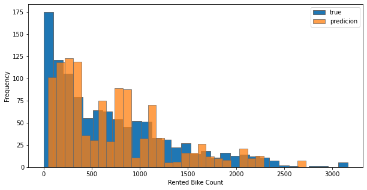

```python
figure = plt.figure(figsize=(10,5))
plt.hist(y_test, bins=31, label="true", edgecolor = 'dimgray')
plt.hist(y_pred2, bins=31, label="predicion", alpha = 0.75, edgecolor = 'dimgray')
plt.legend()
plt.xlabel(rents)
plt.ylabel("Frequency")
plt.show()
```

### Random Forest Regressor

Lastly, we train a random forest regressor.

```python
model3 = RandomForestRegressor(random_state=2022)
model3.fit(X_train, y_train)
y_pred3 = model3.predict(X_test)
```

```python
print("R-squared:", (r2_score(y_test, y_pred3)))
print("MAE:",(mean_absolute_error(y_test, y_pred3)))
print("RMSE:", mean_squared_error(y_test, y_pred3, squared = False))
```

```
R-squared: 0.7588078220662864
MAE: 186.6739311594203
RMSE: 310.8915010229989
```

The random forest regressor seems to give the best performance according to the metrics we used. This can also be seen by plotting the histograms of the test set and our predictions.

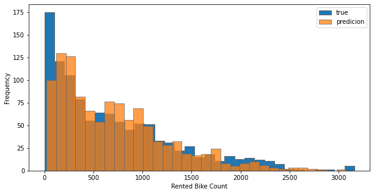

```python
figure = plt.figure(figsize=(10,5))
plt.hist(y_test, bins=31, label="true", edgecolor = 'dimgray')
plt.hist(y_pred3, bins=31, label="predicion", alpha = 0.75, edgecolor = 'dimgray')
plt.legend()
plt.xlabel(rents)
plt.ylabel("Frequency")
plt.show()
```

We define the residual as the difference between the true values and the values predicted by the model. From the scatter plot the residual seems to be high for early morning hours and for certain data points having a rented bike count of 0 (although these differ slighly in each run due to the stochastic nature of the model).

```python
resid = y_test - y_pred3
```

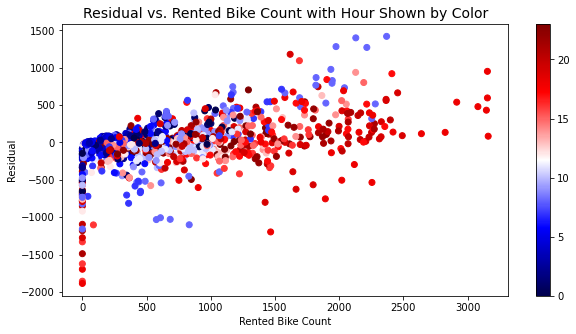

```python
figure = plt.figure(figsize=(10,5))
plt.scatter(y_test, resid, c = X_test['Hour'], cmap = 'seismic')
plt.colorbar()
plt.xlabel("Rented Bike Count")
plt.ylabel("Residual")
plt.title("Residual vs. Rented Bike Count with Hour Shown by Color", fontsize=14)
plt.show()
```

### Interpreting The Random Tree Regressor Model

We use a game-theoretic approach (involving shapley values) to visualise feature importance by using the SHAP library.

```python
!pip install shap
```

```python
import shap
```

```python
texp = shap.TreeExplainer(model3)
vals = texp.shap_values(X_test)
```

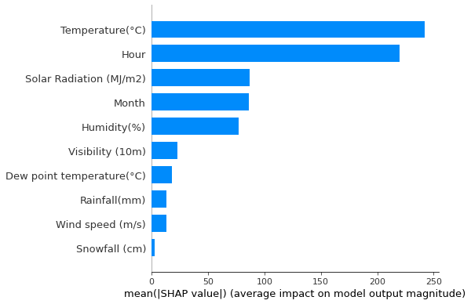

```python
shap.summary_plot(vals, X_test, plot_type="bar")
```

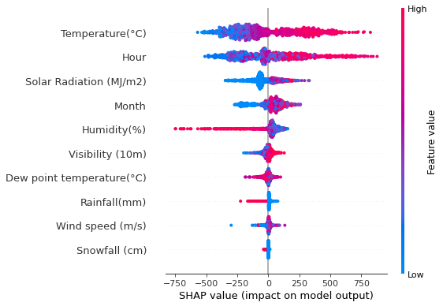

```python
shap.summary_plot(vals, X_test)
```

From both plots we conclude that the random forest regressor model is mostly influenced by the temperature and hour features, along with mild influence from solar radiation, month, and humidity.